# FoodHub Data Analysis

### Context

The number of restaurants in New York is increasing day by day. Lots of students and busy professionals rely on those restaurants due to their hectic lifestyles. Online food delivery service is a great option for them. It provides them with good food from their favorite restaurants. A food aggregator company FoodHub offers access to multiple restaurants through a single smartphone app.

The app allows the restaurants to receive a direct online order from a customer. The app assigns a delivery person from the company to pick up the order after it is confirmed by the restaurant. The delivery person then uses the map to reach the restaurant and waits for the food package. Once the food package is handed over to the delivery person, he/she confirms the pick-up in the app and travels to the customer's location to deliver the food. The delivery person confirms the drop-off in the app after delivering the food package to the customer. The customer can rate the order in the app. The food aggregator earns money by collecting a fixed margin of the delivery order from the restaurants.

### Objective

The food aggregator company has stored the data of the different orders made by the registered customers in their online portal. They want to analyze the data to get a fair idea about the demand of different restaurants which will help them in enhancing their customer experience. Suppose you are hired as a Data Scientist in this company and the Data Science team has shared some of the key questions that need to be answered. Perform the data analysis to find answers to these questions that will help the company to improve the business.

### Data Description

The data contains the different data related to a food order. The detailed data dictionary is given below.

### Data Dictionary

- order_id: Unique ID of the order
- customer_id: ID of the customer who ordered the food
- restaurant_name: Name of the restaurant
- cuisine_type: Cuisine ordered by the customer
- cost: Cost of the order
- day_of_the_week: Indicates whether the order is placed on a weekday or weekend (The weekday is from Monday to Friday and the weekend is Saturday and Sunday)
- rating: Rating given by the customer out of 5
- food_preparation_time: Time (in minutes) taken by the restaurant to prepare the food. This is calculated by taking the difference between the timestamps of the restaurant's order confirmation and the delivery person's pick-up confirmation.
- delivery_time: Time (in minutes) taken by the delivery person to deliver the food package. This is calculated by taking the difference between the timestamps of the delivery person's pick-up confirmation and drop-off information

### Let us start by importing the required libraries

```python
# import libraries for data manipulation
import numpy as np
import pandas as pd

# import libraries for data visualization
import matplotlib.pyplot as plt
import seaborn as sns
```

### Understanding the structure of the data

```python
# let colab access my google drive
from google.colab import drive
drive.mount("/content/drive")
```

```python
# read the data
df = pd.read_csv("/content/drive/MyDrive/foodhub_order.csv")
# Check if Dataset has been imported correctly by verifying the first 20 rows of data
# Transposing matrix for easier visualisation
df.head(10).T
```

|  | 0 | 1 | 2 | 3 | 4 | 5 | 6 | 7 | 8 | 9 |
| --- | --- | --- | --- | --- | --- | --- | --- | --- | --- | --- |
| order_id | 1477147 | 1477685 | 1477070 | 1477334 | 1478249 | 1477224 | 1477894 | 1477859 | 1477174 | 1477311 |
| customer_id | 337525 | 358141 | 66393 | 106968 | 76942 | 147468 | 157711 | 89574 | 121706 | 39705 |
| restaurant_name | Hangawi | Blue Ribbon Sushi Izakaya | Cafe Habana | Blue Ribbon Fried Chicken | Dirty Bird to Go | Tamarind TriBeCa | The Meatball Shop | Barbounia | Anjappar Chettinad | Bukhara Grill |
| cuisine_type | Korean | Japanese | Mexican | American | American | Indian | Italian | Mediterranean | Indian | Indian |
| cost_of_the_order | 30.75 | 12.08 | 12.23 | 29.2 | 11.59 | 25.22 | 6.07 | 5.97 | 16.44 | 7.18 |
| day_of_the_week | Weekend | Weekend | Weekday | Weekend | Weekday | Weekday | Weekend | Weekday | Weekday | Weekday |
| rating | Not given | Not given | 5 | 3 | 4 | 3 | Not given | 3 | 5 | 5 |
| food_preparation_time | 25 | 25 | 23 | 25 | 25 | 20 | 28 | 33 | 21 | 29 |
| delivery_time | 20 | 23 | 28 | 15 | 24 | 24 | 21 | 30 | 26 | 26 |

#### Observations:

The DataFrame has 9 columns as mentioned in the Data Dictionary. Data in each row corresponds to the order placed by a customer.

```python
# Checking shape of the data
print("There are", df.shape[0], "rows and", df.shape[1], "columns.")
```

```
There are 1898 rows and 9 columns.
```

#### Observations:

##### Using Pandas shape() function it is possible to observe that the provided dataset has:

- 1898 Rows
- 9 Columns

```python
# Checking the data types in imported dataset
df.info()
```

```
<class 'pandas.core.frame.DataFrame'>
RangeIndex: 1898 entries, 0 to 1897
Data columns (total 9 columns):
 #   Column                 Non-Null Count  Dtype
---  ------                 --------------  -----
 0   order_id               1898 non-null   int64
 1   customer_id            1898 non-null   int64
 2   restaurant_name        1898 non-null   object
 3   cuisine_type           1898 non-null   object
 4   cost_of_the_order      1898 non-null   float64
 5   day_of_the_week        1898 non-null   object
 6   rating                 1898 non-null   object
 7   food_preparation_time  1898 non-null   int64
 8   delivery_time          1898 non-null   int64
dtypes: float64(1), int64(4), object(4)
memory usage: 133.6+ KB
```

```python
# Checking the count of different data types in "Dtype=object" columns
print(df["restaurant_name"].apply(type).value_counts())
print(df["cuisine_type"].apply(type).value_counts())
print(df["day_of_the_week"].apply(type).value_counts())
print(df["rating"].apply(type).value_counts())
```

```
<class 'str'>    1898
Name: restaurant_name, dtype: int64
<class 'str'>    1898
Name: cuisine_type, dtype: int64
<class 'str'>    1898
Name: day_of_the_week, dtype: int64
<class 'str'>    1898
Name: rating, dtype: int64
```

#### Observations:

##### Using Pandas info() method it is possible to conclude that features:

- "order_id", "customer_id", "food_preparation_time" and "delivery_time" data types are "int64"
- "cost_of_the_order" datatype is "float"
- "restaurant_name", "cuisine_type", "day_of_the_week" and "rating" data types are "object"

##### Analysis of features with Dtype "object" has revealed that they contain only type "str" and will be treated as "categorical" variables.

##### All 9 distinct features in the dataset have the same number of Non-null counts of 1898 entries, indicating that there all entries are present.

### **It is possible to initially conclude that the dataset provided by FoodHub is in good condition to progress further with the Exploratory Data Analysis.**

```python
# Checking for missing values in the data
df.isnull().sum()
```

```
order_id                 0
customer_id              0
restaurant_name          0
cuisine_type             0
cost_of_the_order        0
day_of_the_week          0
rating                   0
food_preparation_time    0
delivery_time            0
dtype: int64
```

```python
# Further visual analysis of unique inputs on each individual feature in the dataset
#df["restaurant_name"].unique()
#df["cuisine_type"].unique()
#df["cost_of_the_order"].unique()
#df["day_of_the_week"].unique()
#df["rating"].unique()
#df["food_preparation_time"].unique()
df["delivery_time"].unique()
```

```
array([20, 23, 28, 15, 24, 21, 30, 26, 22, 17, 25, 16, 29, 27, 18, 31, 32,
       19, 33])
```

```python
# A visual inspection has revealed some special characters in the feature
# "restaurant_name" which causes warnings when plotting some of the data
# The line below will replace any special characters by alphanumerical characters
df["restaurant_name"] = df["restaurant_name"].str.replace("[^a-zA-Z0-9]", "", regex=True)
```

#### Observations:

##### Using the isnull method, it is possible to analyse that there are no values missing in the data. A further visual inspection of unique values on each individual feature available in the dataset also reveals no apparent missing data in the dataset. Code snippet above *(number [27])* only shows "delivery_time" to exemplify the visual inspection in order to avoid cluttering the report.

##### There are however, special characters in the dataset that cause warnings further down in the analysis.

### **The initial analysis has revealed no missing values in the dataset. Special characters have been replaced by alphanumerical characters to avoid warnings further into the analysis**

```python
# Checking the statistical summary of the numeric data first
df.describe().T
```

|  | count | mean | std | min | 25% | 50% | 75% | max |
| --- | --- | --- | --- | --- | --- | --- | --- | --- |
| order_id | 1898.0 | 1.477496e+06 | 548.049724 | 1476547.00 | 1477021.25 | 1477495.50 | 1.477970e+06 | 1478444.00 |
| customer_id | 1898.0 | 1.711685e+05 | 113698.139743 | 1311.00 | 77787.75 | 128600.00 | 2.705250e+05 | 405334.00 |
| cost_of_the_order | 1898.0 | 1.649885e+01 | 7.483812 | 4.47 | 12.08 | 14.14 | 2.229750e+01 | 35.41 |
| food_preparation_time | 1898.0 | 2.737197e+01 | 4.632481 | 20.00 | 23.00 | 27.00 | 3.100000e+01 | 35.00 |
| delivery_time | 1898.0 | 2.416175e+01 | 4.972637 | 15.00 | 20.00 | 25.00 | 2.800000e+01 | 33.00 |

```python
# Checking the statistical summary of the categorical data next
df.describe(include=[object]).T
```

|  | count | unique | top | freq |
| --- | --- | --- | --- | --- |
| restaurant_name | 1898 | 178 | ShakeShack | 219 |
| cuisine_type | 1898 | 14 | American | 584 |
| day_of_the_week | 1898 | 2 | Weekend | 1351 |
| rating | 1898 | 4 | Not given | 736 |

```python
# Particular interest in the statistical summary of feature "food_preparation_time"
df["food_preparation_time"].describe()
```

```
count    1898.000000
mean       27.371970
std         4.632481
min        20.000000
25%        23.000000
50%        27.000000
75%        31.000000
max        35.000000
Name: food_preparation_time, dtype: float64
```

#### Observations:

##### An analysis of statistical summaries of numeric and categorical features has been made. There is a particular interest in the feature "food_preparation_time", specifically minimum, average, and maximum times.

#### **Minimum and maximum preparation times are of 20 and 35 minutes respectively, whilst the average time is of 27.37 minutes**

```python
# Checking the size of DataFrame returned by Pandas shape attribute and a
# conditional search for "Not given" rating values in the dataset
print("There are", df.loc[df["rating"]=="Not given"].shape[0], "orders not rated.")
print("representing", (df.loc[df["rating"]=="Not given"].shape[0] / df.shape[0]) * 100, "percent of all orders.")
```

```
There are 736 orders not rated.
representing 38.77766069546891 percent of all orders.
```

#### Observations:

##### By conditionally searching the "rating" feature of the dataset for "Not given" values will return the value of orders not rated.

#### **Out of 1898 orders, there are 736 orders that are not rated which represents about 38% of all orders.**

### Exploratory Data Analysis (EDA)

### Univariate analysis of "order_id"

```python
# Confirming that there is no relevance in the univariate analysis of "order_id"
# since all values are unique
print("There are", df["order_id"].nunique(), "unique order IDs.")
```

```
There are 1898 unique order IDs.
```

#### _**The feature "unique_ID" is a one-to-one identifier for each entry, rendering a univariate analysis redundant.**_

### Univariate analysis of "customer_id"

```python
# Checking the total number of unique customers in "customer_id"
print("There are", df["customer_id"].nunique(), "unique customer IDs.")
```

```
There are 1200 unique customer IDs.
```

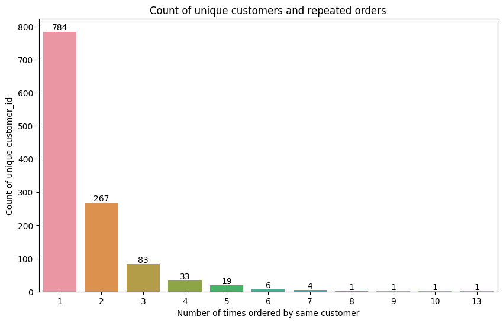

```python
# This study shows the distribution of repeated orders in "customer_id"
# Get counts for each customer ID
customer_counts = df["customer_id"].value_counts()
# Get counts of their frequencies
frequency_counts = customer_counts.value_counts().sort_index()

# Plotting with barplot()
plt.figure(figsize=(10, 6))
plot = sns.barplot(x=frequency_counts.index, y=frequency_counts.values)
# For loop will add the count on top of each bar
for i, count in enumerate(frequency_counts.values):
    plot.text(i, count + 0.1, str(count), ha="center", va="bottom")
#Adding labels
plt.xlabel("Number of times ordered by same customer")
plt.ylabel("Count of unique customer_id")
plt.title("Count of unique customers and repeated orders")
plt.show()
```

**There are 1200 unique customer IDs in the dataset.**

**An analysis of the number of customers that have repeatedly used FoodHub service has revealed a very right skewed distribution, with 784 users using the service only once, representing about 65.3% of all users. The other 34.7% of users have used the service more than once, with 267 customers ordering twice from the service, which is an expressive 22% of total customers in the dataset.**

### Univariate analysis of "restaurant_name"

```python
# Getting the number of unique restaurant names in dataset
print("There are", df["restaurant_name"].nunique(), "unique restaurants in the dataset.")
```

```
There are 178 unique restaurants in the dataset.
```

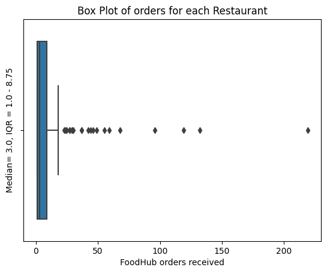

```python
# Calculating the aggregate frequency of restaurant orders by counting the number
# of times each restaurant was used and grouping the counts
restaurant_counts = df["restaurant_name"].value_counts()

# Plotting box plot
sns.boxplot(x=restaurant_counts.values)

# Changing x and y labels. Y label to include Median and IQR
plt.xlabel("FoodHub orders received")
plt.ylabel(f"Median= {restaurant_counts.median()}, IQR = {restaurant_counts.quantile(0.25)} - {restaurant_counts.quantile(0.75)}")
plt.title("Box Plot of orders for each Restaurant")
plt.show()
```

#### _**Analysis of "restaurant_name" feature reveals that the majority of restaurants have received between 1 and 8.75 orders from FoodHub platform, with a median of 3 orders.**_

#### **One particular outlier has received in excess of 200 orders from the FoodHub platform.**

### Univariate analysis of "cuisine_type"

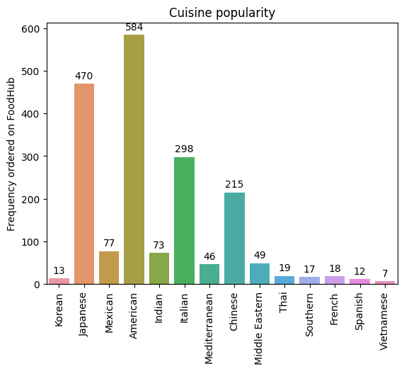

```python
# Univariate analysis of the feature "cuisine_type"
plt.title("Cuisine popularity")
cuisine_pop = sns.countplot(data=df, x="cuisine_type")
# Rotating font in order to avoid cluttering of words
plt.xticks(rotation=90)
plt.xlabel("")
plt.ylabel("Frequency ordered on FoodHub")
# Add count labels on top of each bar
for p in cuisine_pop.patches:
    cuisine_pop.annotate(f'{int(p.get_height())}', (p.get_x() + p.get_width() / 2., p.get_height()),
                ha="center", va="center", xytext=(0, 8), textcoords="offset points")
plt.show()
```

#### _**Analysis of "cuisine_type" feature reveales that American cuisine is the most popular amongst FoodHub users, followed by Japanese, Italian and Chinese in that order.**_

### Univariate analysis of "cost_of_the_order"

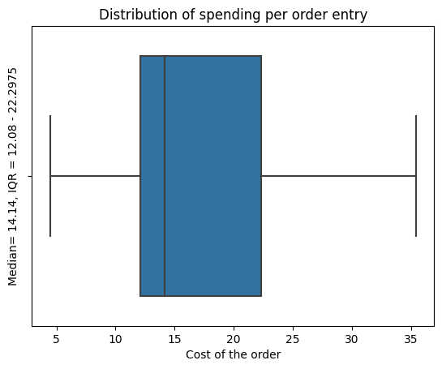

```python
#Distribution of the "Income" variable:
plt.title("Distribution of spending per order entry")
sns.boxplot(data=df, x="cost_of_the_order")
# Changing x and y labels. Y label to include Median and IQR
plt.xlabel("Cost of the order")
plt.ylabel(f"Median= {df['cost_of_the_order'].median()}, IQR = {df['cost_of_the_order'].quantile(0.25)} - {df['cost_of_the_order'].quantile(0.75)}")
plt.show()
```

#### _**An analysis of the "cost_of_the_order" feature reveals that FoodHub users spend between 12.08 and 22.30, with a median of 14.14.**_

### Univariate analysis of "day_of_the_week"

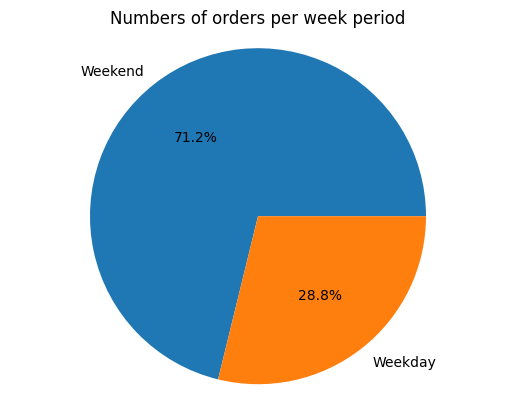

```python
# Univariate analysis of the feature "day_of_the_week"
plt.title("Numbers of orders per week period")
# Calculate counts
day_of_week_counts = df["day_of_the_week"].value_counts()

# Create a pie chart
plt.pie(day_of_week_counts, labels=day_of_week_counts.index, autopct="%1.1f%%")
plt.axis("equal")  # Equal aspect ratio ensures that pie is drawn as a circle.
plt.show()
```

#### _**An Analysis of the "day_of_the_week" feature has revealed that 71.2% of the orders on FoodHub are placed on Weekends.**_

### Univariate analysis of "rating"

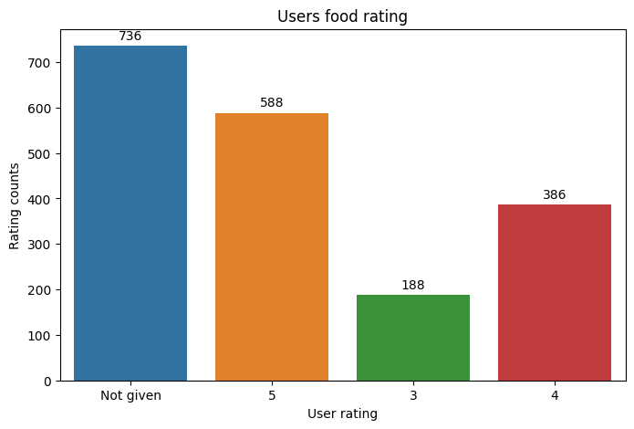

```python
# Univariate analysis of the feature "rating"
plt.figure(figsize=(8, 5))
plt.title("Users food rating")
rating = sns.countplot(data=df, x="rating")
# Changing x and y axis labels
plt.xlabel("User rating")
plt.ylabel("Rating counts")
# Add count labels on top of each bar
for p in rating.patches:
    rating.annotate(f'{int(p.get_height())}', (p.get_x() + p.get_width()/2, p.get_height()),
                ha="center", va="center", xytext=(0, 8), textcoords="offset points")
plt.show()
```

### Univariate analysis of "food_preparation_time"

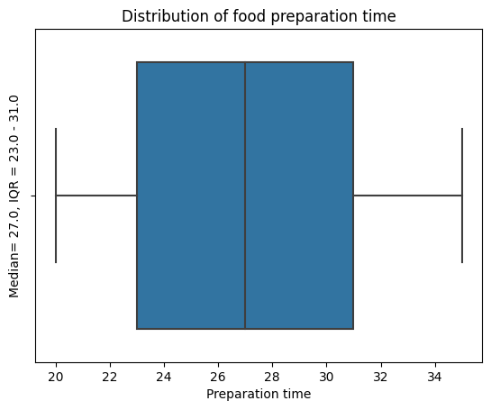

```python
#Distribution of the "food_preparation_time" variable:
plt.title("Distribution of food preparation time")
sns.boxplot(data=df, x="food_preparation_time")
# Changing x and y labels. Y label to include Median and IQR
plt.xlabel("Preparation time")
plt.ylabel(f"Median= {df['food_preparation_time'].median()}, IQR = {df['food_preparation_time'].quantile(0.25)} - {df['food_preparation_time'].quantile(0.75)}")
plt.show()
```

#### _**An Analysis of the "food_preparation_time" feature reveals that restaurants mostly take between 23 to 31 minutes to prepare the food, with the median being 27 minutes.**_

### Univariate analysis of "delivery_time"

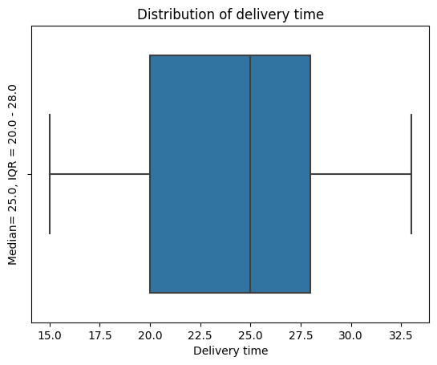

```python
#Distribution of the "delivery_time" variable:
plt.title("Distribution of delivery time")
sns.boxplot(data=df, x="delivery_time")
# Changing x and y labels. Y label to include Median and IQR
plt.xlabel("Delivery time")
plt.ylabel(f"Median= {df['delivery_time'].median()}, IQR = {df['delivery_time'].quantile(0.25)} - {df['delivery_time'].quantile(0.75)}")
plt.show()
```

#### _**An Analysis of the "delivery_time" feature reveals that food mostly takes between 20 to 28 minutes to be delivered, with the median being 25 minutes.**_

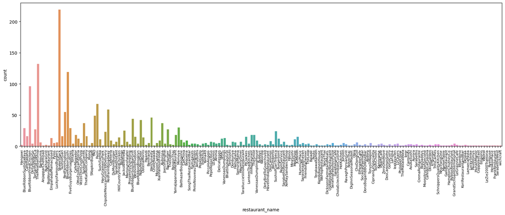

```python
# Changing size of plot due to number of categories
plt.figure(figsize=(20, 6))
# Creating countplot with the feature "restaurant_name"
sns.countplot(data=df, x="restaurant_name")
# Rotating font in order to avoid cluttering names
plt.xticks(rotation=90, fontsize=8)
plt.show()
```

```python
# Print 5 top restaurants on FoodHub in terms of the number of orders received
(df["restaurant_name"].value_counts(normalize=False)).head()
```

```
ShakeShack                219
TheMeatballShop           132
BlueRibbonSushi           119
BlueRibbonFriedChicken     96
Parm                       68
Name: restaurant_name, dtype: int64
```

```python
# Print 5 top restaurants on FoodHub in terms of the number of orders received by percentage
(df["restaurant_name"].value_counts(normalize=True) * 100).head()
```

```
ShakeShack                11.538462
TheMeatballShop            6.954689
BlueRibbonSushi            6.269758
BlueRibbonFriedChicken     5.057956
Parm                       3.582719
Name: restaurant_name, dtype: float64
```

#### Observations:

#### **The top 5 restaurants on FoodHub in terms of the number of orders received are:**

1. ShakeShack with 219 orders, representing 11.5% of all orders
2. TheMeatballShop with 132 orders, representing 6.95% of all orders
3. BlueRibbonSushi with 119 orders, representing 6.27% of all orders
4. BlueRibbonFriedChicken with 96 orders, representing 5.06% of all orders
5. Parm with 68 orders, representing 3.58% of all orders

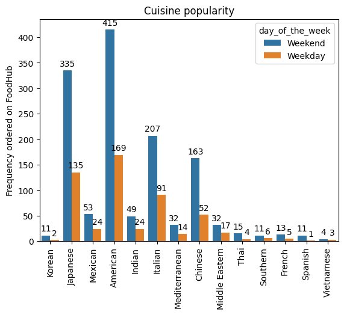

```python
# Write the code here
# Univariate analysis of the feature "cuisine_type"
plt.title("Cuisine popularity")
cuisine_pop = sns.countplot(data=df, x="cuisine_type", hue="day_of_the_week")
# Rotating font in order to avoid cluttering of names
plt.xticks(rotation=90)
plt.xlabel("")
plt.ylabel("Frequency ordered on FoodHub")
# Add count labels on top of each bar
for p in cuisine_pop.patches:
    cuisine_pop.annotate(f'{int(p.get_height())}', (p.get_x() + p.get_width() / 2., p.get_height()),
                ha="center", va="center", xytext=(0, 8), textcoords="offset points")
plt.show()
```

```python
# Return the counts of cuisine types on Weekends only
pop_weekend = df.loc[df["day_of_the_week"]=="Weekend","cuisine_type"].value_counts()
# Same as above, but percentages
pop_wknd_perc = df.loc[df["day_of_the_week"]=="Weekend","cuisine_type"].value_counts(normalize=True) * 100
# Print answer
print(pop_weekend.index[0], "is the most popular cuisine on weekends, with", pop_weekend[0], "total orders representing", pop_wknd_perc[0], "percent of the total weekend orders.")
```

```
American is the most popular cuisine on weekends, with 415 total orders representing 30.717986676535897 percent of the total weekend orders.
```

#### Observations:

#### **American is the most popular cuisine on weekends, with 415 total orders representing 30.7% of the total weekend orders.**

```python
# Conditional .loc[] with shape[0] method returns the numbers of rows of the
# conditional search return. df.shape[0] does the same but for the whole matrix
orders_20plus = (df.loc[df["cost_of_the_order"]>20].shape[0] / df.shape[0]) * 100
print(orders_20plus, "percent of orders cost more than 20 dollars")
```

```
29.24130663856691 percent of orders cost more than 20 dollars
```

#### Observations:

#### **About 29.2% of the orders placed on FoodHub cost more than 20 dollars.**

```python
# Calculating the mean of "delivery_time"
delivery_time_mean = df["delivery_time"].mean()
print("The mean delivery time is", delivery_time_mean)
```

```
The mean delivery time is 24.161749209694417
```

#### Observations:

#### **The mean/average order delivery time is 24.16 minutes.**

```python
# Print only top 3 FoodHub customer_ids
(df["customer_id"].value_counts()).head(3)
```

```
52832    13
47440    10
83287     9
Name: customer_id, dtype: int64
```

#### Observations:

#### _**The top 3 FoodHub customer_ids are:**_

1. Customer ID 52832 with 13 orders
2. Customer ID 47440 with 10 orders
3. Customer ID 83287 with 9 orders

### Multivariate Analysis

```python
# Making a copy of the DataFrame to keep original intact
remove_norate = df.copy()
# Replace "Not given" rating to NaN and converting values in row from object to float
# This will convert "rating" from a categorical to a numeric feature
remove_norate["rating"] = (df["rating"].replace(["Not given"],np.nan)).astype(float)
```

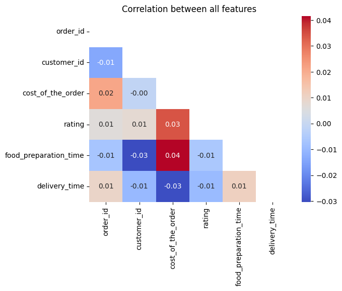

```python
# Checking correlation between all features
correlation_matrix = remove_norate[["order_id",
                     "customer_id",
                     "restaurant_name",
                     "cuisine_type",
                     "cost_of_the_order",
                     "day_of_the_week",
                     "rating",
                     "food_preparation_time",
                     "delivery_time"]].corr(numeric_only=True)
# Create a triangular mask
mask = np.triu(np.ones_like(correlation_matrix, dtype=bool))
plt.title("Correlation between all features")
sns.heatmap(correlation_matrix, annot=True, cmap="coolwarm", fmt=".2f", mask=mask)
plt.show()
```

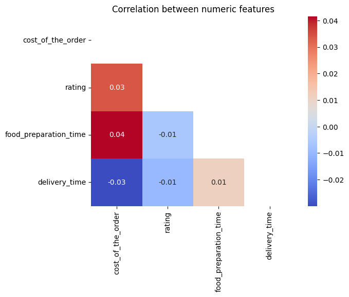

```python
# Checking correlation between numeric features
correlation_matrix = remove_norate[["cost_of_the_order",
                                    "rating",
                                    "food_preparation_time",
                                    "delivery_time"]].corr()
# Create a triangular mask
mask = np.triu(np.ones_like(correlation_matrix, dtype=bool))
plt.title("Correlation between numeric features")
sns.heatmap(correlation_matrix, annot=True, cmap="coolwarm", fmt=".2f", mask=mask)
plt.show()
```

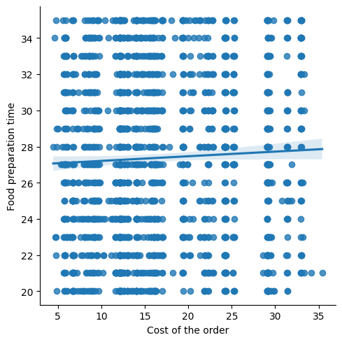

```python
# Plotting linear model of cost_of_the_order x food_preparation_time
sns.lmplot(data=remove_norate, x="cost_of_the_order", y="food_preparation_time")
plt.xlabel("Cost of the order")
plt.ylabel("Food preparation time")
plt.show()
```

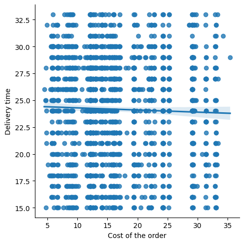

```python
# Plotting linear model of cost_of_the_order x delivery_time
sns.lmplot(data=remove_norate, y="delivery_time", x="cost_of_the_order")
plt.xlabel("Cost of the order")
plt.ylabel("Delivery time")
plt.show()
```

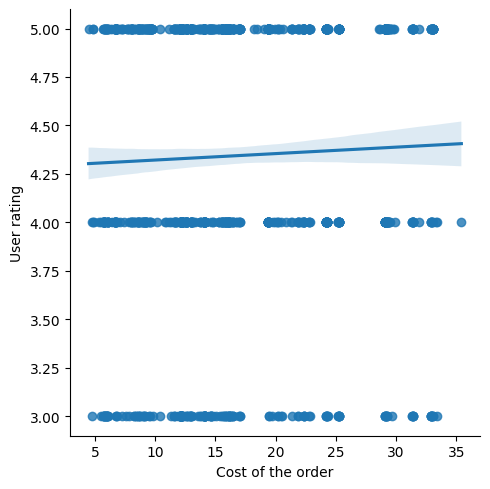

```python
# Plotting linear model of cost_of_the_order x delivery_time
sns.lmplot(data=remove_norate, y="rating", x="cost_of_the_order")
plt.xlabel("Cost of the order")
plt.ylabel("User rating")
plt.show()
```

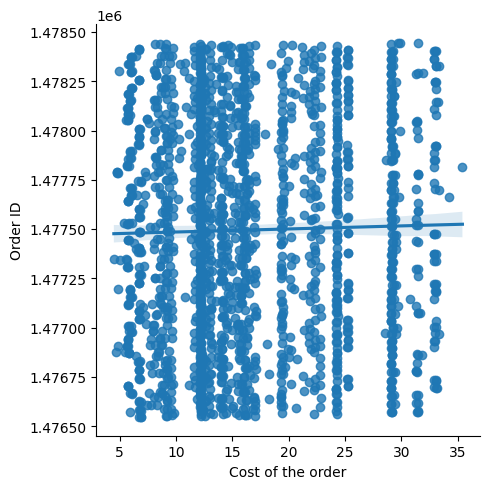

```python
# Plotting linear model of cost_of_the_order x delivery_time
sns.lmplot(data=remove_norate, y="order_id", x="cost_of_the_order")
plt.xlabel("Cost of the order")
plt.ylabel("Order ID")
plt.show()
```

#### **The analysis of correlation between numeric features in the dataset reveals that:**

#### Observations:

- There is slight negative correlation (-0.03) between cost_of_the_order x delivery_time.
- There is slight positive correlation (0.03) between cost_of_the_order x rating, perhaps indicating users that spend more are likely to score a higher rating.
- There is slight positive correlation (0.04) between cost_of_the_order x food_preparation_time, perhaps because the larger the cost, the more items the order has.
- There is a slight positive correlation (0.02) between "order_id" and "cost_of_the_order". If "order_id" in the system is generated in an increasing order, it perhaps indicates that as the platform grows, people are more confident in spending more with large orders.

### **Overall, the correlations are not significant, indicating a weak linear relationship between the variables.**

```python
# Stats of cost of the order by day of the week
df.groupby("day_of_the_week")["cost_of_the_order"].describe()
```

| day_of_the_week | count | mean | std | min | 25% | 50% | 75% | max |
| --- | --- | --- | --- | --- | --- | --- | --- | --- |
| Weekday | 547.0 | 16.311188 | 7.479521 | 4.75 | 12.08 | 14.07 | 22.285 | 35.41 |
| Weekend | 1351.0 | 16.574833 | 7.486979 | 4.47 | 12.08 | 14.41 | 22.285 | 33.37 |

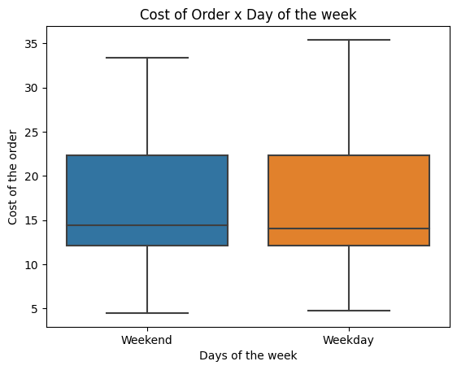

```python
# Analysing the distribution of cost of the order by day of the week
sns.boxplot(data=remove_norate, x="day_of_the_week", y="cost_of_the_order")
plt.title("Cost of Order x Day of the week")
plt.xlabel("Days of the week")
plt.ylabel("Cost of the order")
plt.show()
```

#### Observations:

#### A visual analysis of the distribution of cost of the order by weekdays shows a slightly longer upper whisker on weekdays, indicating a slighly more right skewed distribution. Median and IQR are practically the same on weekend and weekdays.

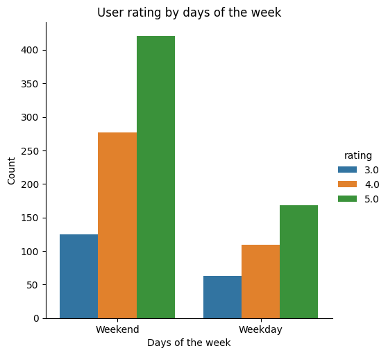

```python
# Categorical plot for "day_of_the_week"
catplot_day_of_week = sns.catplot(data=remove_norate, x="day_of_the_week", kind="count", hue="rating")
plt.title("User rating by days of the week")
plt.xlabel("Days of the week")
plt.ylabel("Count")
plt.show()
```

#### There is an overall lower number of ratings count during weekdays, but the proportion of ratings look very similar between weekdays and weekends.

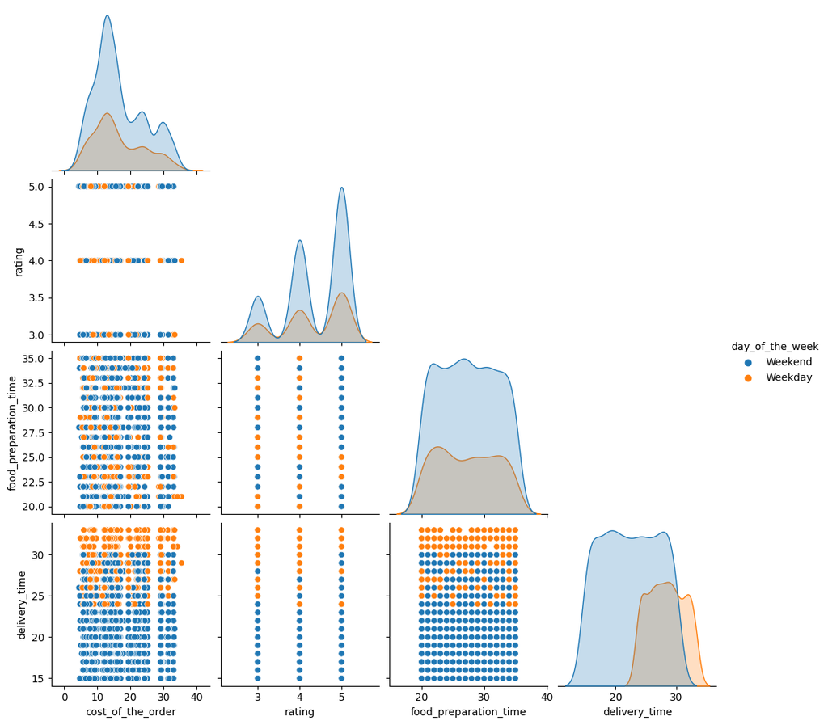

```python
# Visual analysis of numeric features, grouped by days of the week
# Removing redundant plots on the upper diagonal
sns.pairplot(remove_norate,
             vars=["cost_of_the_order", "rating", "food_preparation_time", "delivery_time"],
             hue="day_of_the_week",
             corner=True)
plt.show()
```

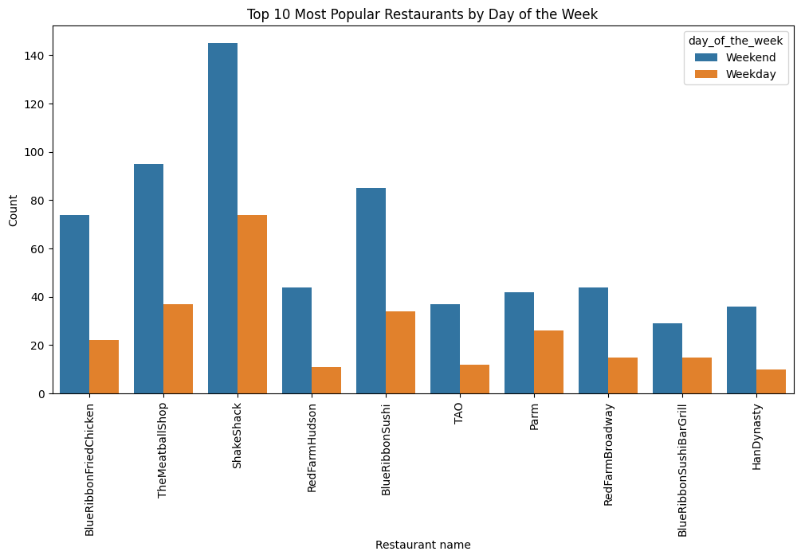

```python
# Analysis of the 10 top restaurants by number of orders x day of the week
# Get the 10 most popular restaurants
top_restaurants = remove_norate["restaurant_name"].value_counts().nlargest(10).index

# Filter the DataFrame for the top restaurants
top_restaurants_data = remove_norate[remove_norate["restaurant_name"].isin(top_restaurants)]

# Create the countplot
plt.figure(figsize=(12, 6))
sns.countplot(data=top_restaurants_data, x="restaurant_name", hue="day_of_the_week")
plt.title("Top 10 Most Popular Restaurants by Day of the Week")
# Rotating font in order to avoid cluttering names
plt.xticks(rotation=90)
plt.xlabel("Restaurant name")
plt.ylabel("Count")
plt.show()
```

#### Cuisine popularity seems to be consistent during weekdays and weekends. Parm restaurant, which is the Top 5 restaurant in popularity count, stands out for having a relatively equal popularity during weekdays and weekends.

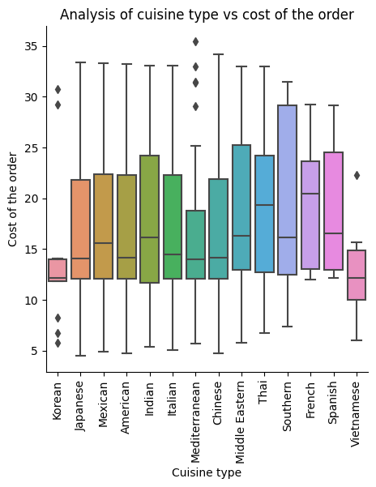

```python
# Analysis of cuisine type vs cost of the order
sns.catplot(data=remove_norate, x="cuisine_type", y="cost_of_the_order", kind="box")
plt.title("Analysis of cuisine type vs cost of the order")
# Rotating font in order to avoid cluttering names
plt.xticks(rotation=90)
plt.xlabel("Cuisine type")
plt.ylabel("Cost of the order")
plt.show()
```

#### The analysis of cuisine type vs cost of order reveals that:

- Mediterranean cuisine has a few outliers on the top end.
- French and Thai have higher median, perhaps indicating that people are willing to spend more for those types of food.
- Korean and Vietnamese cuisine distributions are quite compressed at the bottom end of the cost of order. Perhaps popularity of Korean and Vietnamese cuisines could be increased with some more advertisement by FoodHub platform or suggesting those types of cuisine directly to the customer.

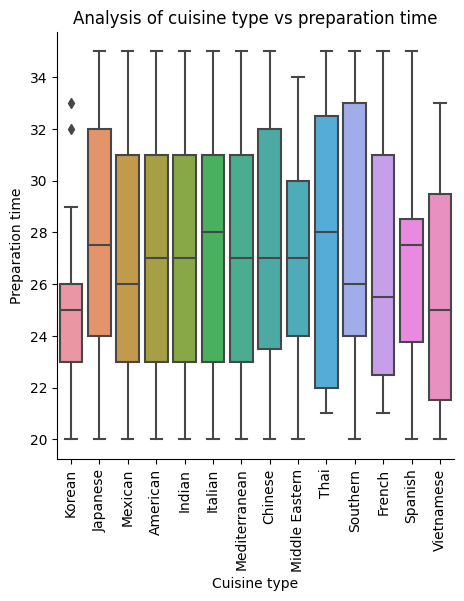

```python
# Analysis of cuisine type and cost of the order
sns.catplot(data=remove_norate, x="cuisine_type", y="food_preparation_time", kind="box")
plt.title("Analysis of cuisine type vs preparation time")
# Rotating font in order to avoid cluttering names
plt.xticks(rotation=90)
plt.xlabel("Cuisine type")
plt.ylabel("Preparation time")
plt.show()
```

#### From an analysis of cuisine type and preparation time it is possible to observe that Spanish and Korean cuisines have lower IQR values than other cuisine types. It could perhaps be concluded that restaurants that focus on these cuisine types can turnover a greater number of orders.

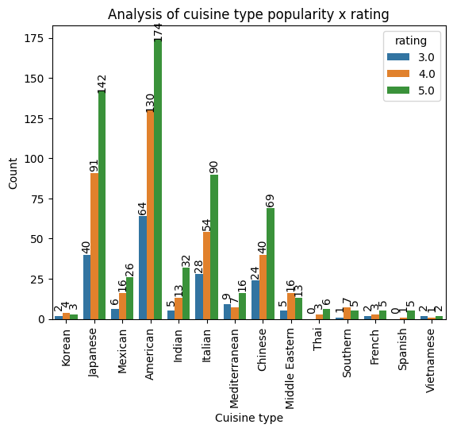

```python
# Analysis of cuisine type and cost of the order
cuisine_pop = sns.countplot(data=remove_norate, x="cuisine_type", hue="rating")
plt.title("Analysis of cuisine type popularity x rating")
# Rotating font in order to avoid cluttering names
plt.xticks(rotation=90)
plt.xlabel("Cuisine type")
plt.ylabel("Count")
# Add count labels on top of each bar
for p in cuisine_pop.patches:
    cuisine_pop.annotate(f'{int(p.get_height())}', (p.get_x() + p.get_width() / 2., p.get_height()),
                ha="center", va="center", xytext=(0, 8), textcoords="offset points", rotation="vertical")
plt.show()
```

#### An analysis of the cuisine type and their user rating reveals that Korean, Middle Eastern and Southern cuisines have lower overall rating, with more users rating it a 4, than users rating it a 5. Perhaps bringing better quality restaurants to the platform for a more diverse audience would increase revenue.

```python
# Making a copy of the DataFrame to keep original intact
remove_norate = df.copy()
# Replace "Not given" rating to NaN and converting values in row from object to float
remove_norate["rating"] = (df["rating"].replace(["Not given"],np.nan)).astype(float)
# Calculate average rating and rating count for each restaurant
restaurant_stats = remove_norate.groupby("restaurant_name")["rating"].agg(["mean", "count"]).reset_index()
# Applying the conditions using .loc
met_condition = restaurant_stats.loc[(restaurant_stats["count"] > 50) & (restaurant_stats["mean"] > 4), "restaurant_name"]
# Iterate through rows and print their total number of scores and average score
for i in range(met_condition.shape[0]):
  print(met_condition.iloc[i], ", Mean =", restaurant_stats["mean"][met_condition.index[i]], ", Count =", restaurant_stats["count"][met_condition.index[i]])
```

```
BlueRibbonFriedChicken , Mean = 4.328125 , Count = 64
BlueRibbonSushi , Mean = 4.219178082191781 , Count = 73
ShakeShack , Mean = 4.2781954887218046 , Count = 133
TheMeatballShop , Mean = 4.511904761904762 , Count = 84
```

#### Observations:

#### **The following restaurants fullfill the criteria of rating count greater than 50 and the average rating greater than 4:**

1. TheMeatballShop with a score count of 84 and a mean score of 4.51
2. BlueRibbonFriedChicken with a score count of 64 and a mean score of 4.33
3. ShakeShack with a score count of 133 and a mean score of 4.28
4. BlueRibbonSushi with a score count of 73 and a mean score of 4.22

```python
# Calculate net revenue for orders cost between 5 and 20 dollars
rev_15 = df.loc[(df["cost_of_the_order"] > 5) & (df["cost_of_the_order"] < 20), "cost_of_the_order"].sum() * 0.15
# Calculate net revenue for orders greater than 20 dollars
rev_25 = df.loc[df["cost_of_the_order"] > 20, "cost_of_the_order"].sum() * 0.25
print("Total revenue generated by the company across all orders is $", rev_15 + rev_25)
```

```
Total revenue generated by the company across all orders is $ 6166.303
```

#### Observations:

#### **Total revenue generated by the company across all orders is $6166.30**

```python
# Sum both preparation time and delivery times and return the count of orders
# that exceed 60 minutes
slow_orders = df.loc[(df["food_preparation_time"]+df["delivery_time"]) > 60].shape[0]
print(slow_orders, "orders exceed 60 minutes to get delivered from the time the order is placed")
print("which represents", (slow_orders / df.shape[0]) * 100, "percent of all orders")
```

```
200 orders exceed 60 minutes to get delivered from the time the order is placed
which represents 10.537407797681771 percent of all orders
```

#### Observations:

#### **200 orders exceed 60 minutes to get delivered from the time the order is placed, which represents 10.54% of all orders.**

```python
# Write the code here
print("Weekdays average =", df.loc[df["day_of_the_week"]=="Weekday","delivery_time"].mean(), "minutes.")
print("Weekend average =", df.loc[df["day_of_the_week"]=="Weekend","delivery_time"].mean(), "minutes.")
```

```
Weekdays average = 28.340036563071298 minutes.
Weekend average = 22.4700222057735 minutes.
```

### Recommendations:

- **Customer Engagement**: *Introduce loyalty programs or exclusive offers for repeat customers to increase retention. The majority of orders are placed on weekends, suggesting focused marketing efforts on weekdays can boost order counts.*
- **Restaurant Collaboration**: *Establish partnerships with top restaurants for mutual promotion and increased visibility. Encourage restaurants to maintain high ratings to be eligible for promotional offers and encourage customer to rate their orders.*
- **Cuisine Diversity**: *American cuisine is the most popular but diversifying cuisine options could attract a broader customer base. Encourage a diverse range of cuisines to attract a wider audience. Promote less popular cuisines to increase their visibility and customer base (e.g. Korean and Vietnamese).*
- **Operational Efficiency**: *Work with restaurants with efficient food preparation times to enhance overall delivery speed (e.g. Spanish and Korean). Efficient turnover for specific cuisines suggests potential for collaboration with faster-preparing restaurants. Implement measures to ensure timely deliveries for customer satisfaction.*
- **Marketing Strategy**: *Leverage customer ratings and feedback to improve overall service quality. Insights from multivariate analysis may help tailor marketing strategies for specific cuisines.*
- **Revenue Optimization**: *Explore revenue-sharing models to incentivize restaurants with higher order costs. Offer discounts during peak hours to encourage more orders.*
- **Customer Communication**: *Encourage customers to provide ratings and feedback through incentives.*

## **By implementing these recommendations, FoodHub can enhance customer satisfaction, attract more restaurants, and optimize revenue streams. Regular data monitoring and feedback analysis will be essential for continuous improvement.**